# finding_donors

## Project: Finding Donors for *CharityML*

In this project, I have employed several supervised algorithms to accurately model individuals' income using data collected from the 1994 U.S. Census. The goal is to construct a model that accurately predicts whether an individual makes more than $50,000. This sort of task can arise in a non-profit setting, where organizations survive on donations. Understanding an individual's income can help a non-profit better understand how large of a donation to request, or whether or not they should reach out to begin with. While it can be difficult to determine an individual's general income bracket directly from public sources, we can (as we will see) infer this value from other publically available features.

## Dataset

The dataset for this project originates from the [UCI Machine Learning Repository](https://archive.ics.uci.edu/ml/datasets/Census+Income). The datset was donated by Ron Kohavi and Barry Becker, after being published in the article *"Scaling Up the Accuracy of Naive-Bayes Classifiers: A Decision-Tree Hybrid"*. You can find the article by Ron Kohavi [online](https://www.aaai.org/Papers/KDD/1996/KDD96-033.pdf). The data we investigate here consists of small changes to the original dataset, such as removing the `'fnlwgt'` feature and records with missing or ill-formatted entries.

## Outline

The notebook is divided into separate steps. Feel free to use the links below to navigate the notebook.

- Step 0: Import Datasets
- Step 1: Data Exploration
- Step 2: Data Preprocessing
- Step 3: Evaluating Model Performance
- Step 4: Improving Results
- Step 5: Feature Importance

## Step 0: Import Datasets

```python
# Import libraries necessary for this project
import numpy as np
import pandas as pd
from time import time
from IPython.display import display # Allows the use of display() for DataFrames

# Import supplementary visualization code visuals.py
import visuals as vs

# Pretty display for notebooks
%matplotlib inline

# Load the Census dataset
data = pd.read_csv("census.csv")

# Success - Display the first record
display(data.head(n=1))
```

|  | age | workclass | education_level | education-num | marital-status | occupation | relationship | race | sex | capital-gain | capital-loss | hours-per-week | native-country | income |
| --- | --- | --- | --- | --- | --- | --- | --- | --- | --- | --- | --- | --- | --- | --- |
| 0 | 39 | State-gov | Bachelors | 13.0 | Never-married | Adm-clerical | Not-in-family | White | Male | 2174.0 | 0.0 | 40.0 | United-States | <=50K |

## Step 1: Data Exploration

A cursory investigation of the dataset will determine how many individuals fit into either group, and will tell us about the percentage of these individuals making more than \$50,000.

```
Total number of records: 45222
Individuals making more than $50,000: 11208
Individuals making at most $50,000: 34014
Percentage of individuals making more than $50,000: 24.78%
```

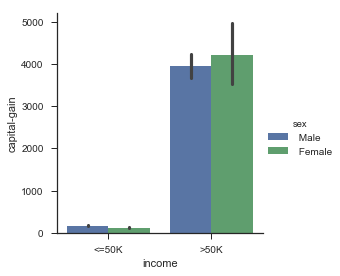

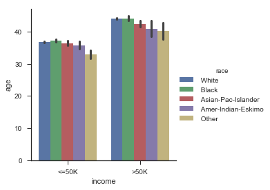

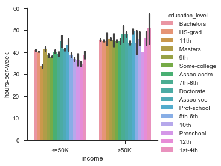

```python
# Total number of records
n_records = data.shape[0]

# Number of records where individual's income is more than $50,000
n_greater_50k = data[data.income == '>50K'].shape[0]

# Number of records where individual's income is at most $50,000
n_at_most_50k = data[data.income == '<=50K'].shape[0]

# Percentage of individuals whose income is more than $50,000
greater_percent = float(n_greater_50k) / float(n_records) * 100

# Print the results
print "Total number of records: {}".format(n_records)
print "Individuals making more than $50,000: {}".format(n_greater_50k)
print "Individuals making at most $50,000: {}".format(n_at_most_50k)
print "Percentage of individuals making more than $50,000: {:.2f}%".format(greater_percent)

#Some factorplots to explore the dataset
import seaborn as sns
sns.factorplot('income','capital-gain',hue='sex',data = data, kind = 'bar')
sns.factorplot('income','age',hue='race',data = data, kind = 'bar')
sns.factorplot('income','hours-per-week',hue='education_level',data = data, kind = 'bar')
```

**Featureset Exploration**

- **age**: continuous.
- **workclass**: Private, Self-emp-not-inc, Self-emp-inc, Federal-gov, Local-gov, State-gov, Without-pay, Never-worked.
- **education**: Bachelors, Some-college, 11th, HS-grad, Prof-school, Assoc-acdm, Assoc-voc, 9th, 7th-8th, 12th, Masters, 1st-4th, 10th, Doctorate, 5th-6th, Preschool.
- **education-num**: continuous.
- **marital-status**: Married-civ-spouse, Divorced, Never-married, Separated, Widowed, Married-spouse-absent, Married-AF-spouse.
- **occupation**: Tech-support, Craft-repair, Other-service, Sales, Exec-managerial, Prof-specialty, Handlers-cleaners, Machine-op-inspct, Adm-clerical, Farming-fishing, Transport-moving, Priv-house-serv, Protective-serv, Armed-Forces.
- **relationship**: Wife, Own-child, Husband, Not-in-family, Other-relative, Unmarried.
- **race**: Black, White, Asian-Pac-Islander, Amer-Indian-Eskimo, Other.
- **sex**: Female, Male.
- **capital-gain**: continuous.
- **capital-loss**: continuous.
- **hours-per-week**: continuous.
- **native-country**: United-States, Cambodia, England, Puerto-Rico, Canada, Germany, Outlying-US(Guam-USVI-etc), India, Japan, Greece, South, China, Cuba, Iran, Honduras, Philippines, Italy, Poland, Jamaica, Vietnam, Mexico, Portugal, Ireland, France, Dominican-Republic, Laos, Ecuador, Taiwan, Haiti, Columbia, Hungary, Guatemala, Nicaragua, Scotland, Thailand, Yugoslavia, El-Salvador, Trinadad&Tobago, Peru, Hong, Holand-Netherlands.

## Step 2: Data Preprocessing

### Transforming Skewed Continuous Features

A dataset may sometimes contain at least one feature whose values tend to lie near a single number, but will also have a non-trivial number of vastly larger or smaller values than that single number. Algorithms can be sensitive to such distributions of values and can underperform if the range is not properly normalized. With the census dataset two features fit this description: '`capital-gain'` and `'capital-loss'`.

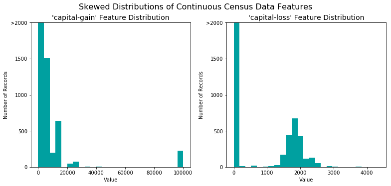

```python
# Split the data into features and target label
income_raw = data['income']
features_raw = data.drop('income', axis = 1)

# Visualize skewed continuous features of original data
vs.distribution(data)
```

For highly-skewed feature distributions such as `'capital-gain'` and `'capital-loss'`, it is common practice to apply a logarithmic transformation on the data so that the very large and very small values do not negatively affect the performance of a learning algorithm. Using a logarithmic transformation significantly reduces the range of values caused by outliers. Care must be taken when applying this transformation however: The logarithm of `0` is undefined, so we must translate the values by a small amount above `0` to apply the the logarithm successfully.

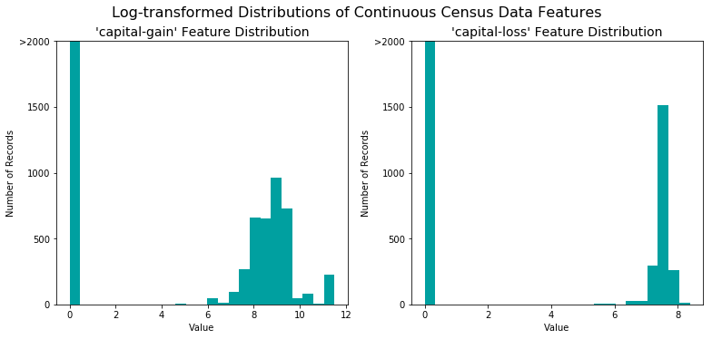

```python
# Log-transform the skewed features
skewed = ['capital-gain', 'capital-loss']
features_log_transformed = pd.DataFrame(data = features_raw)
features_log_transformed[skewed] = features_raw[skewed].apply(lambda x: np.log(x + 1))

# Visualize the new log distributions
vs.distribution(features_log_transformed, transformed = True)
```

### Normalizing Numerical Features

In addition to performing transformations on features that are highly skewed, it is often good practice to perform some type of scaling on numerical features. Applying a scaling to the data does not change the shape of each feature's distribution (such as `'capital-gain'` or `'capital-loss'` above); however, normalization ensures that each feature is treated equally when applying supervised learners.

```python
# Import sklearn.preprocessing.StandardScaler
from sklearn.preprocessing import MinMaxScaler

# Initialize a scaler, then apply it to the features
scaler = MinMaxScaler() # default=(0, 1)
numerical = ['age', 'education-num', 'capital-gain', 'capital-loss', 'hours-per-week']

features_log_minmax_transform = pd.DataFrame(data = features_log_transformed)
features_log_minmax_transform[numerical] = scaler.fit_transform(features_log_transformed[numerical])

# Show an example of a record with scaling applied
display(features_log_minmax_transform.head(n = 1))
```

|  | age | workclass | education_level | education-num | marital-status | occupation | relationship | race | sex | capital-gain | capital-loss | hours-per-week | native-country |
| --- | --- | --- | --- | --- | --- | --- | --- | --- | --- | --- | --- | --- | --- |
| 0 | 0.30137 | State-gov | Bachelors | 0.8 | Never-married | Adm-clerical | Not-in-family | White | Male | 0.667492 | 0.0 | 0.397959 | United-States |

### One-hot encoding

From the table in **Exploring the Data** above, we can see there are several features for each record that are non-numeric. Typically, learning algorithms expect input to be numeric, which requires that non-numeric features (called *categorical variables*) be converted. One popular way to convert categorical variables is by using the **one-hot encoding** scheme. One-hot encoding creates a *"dummy"* variable for each possible category of each non-numeric feature.

```python
# One-hot encode the 'features_log_minmax_transform' data using pandas.get_dummies()
features_final = pd.get_dummies(features_log_minmax_transform)

# Encode the 'income_raw' data to numerical values
#income = data.income.apply(lambda x:1 if x == '>50K' else 0)
#LabelEncoder suitable for a large categorical range of values
from sklearn.preprocessing import LabelEncoder
le = LabelEncoder()
income = le.fit_transform(income_raw)

# Print the number of features after one-hot encoding
encoded = list(features_final.columns)
print "{} total features after one-hot encoding.".format(len(encoded))

# Uncomment the following line to see the encoded feature names
#print encoded
```

```
103 total features after one-hot encoding.
```

### Shuffle and Split Data

Now all *categorical variables* have been converted into numerical features, and all numerical features have been normalized. As always, we will now split the data (both features and their labels) into training and test sets. 80% of the data will be used for training and 20% for testing.

```python
# Import train_test_split
from sklearn.cross_validation import train_test_split

# Split the 'features' and 'income' data into training and testing sets
#Learn from Reviewer: address unbalanced data using stratified K-fold and stratified shuffle split cross validation
X_train, X_test, y_train, y_test = train_test_split(features_final,
                                                    income,
                                                    stratify = income,
                                                    test_size = 0.2,
                                                    random_state = 0)

# Show the results of the split
print "Training set has {} samples.".format(X_train.shape[0])
print "Testing set has {} samples.".format(X_test.shape[0])
```

```
Training set has 36177 samples.
Testing set has 9045 samples.
```

## Step 3: Evaluating Model Performance

### Metrics and the Naive Predictor

*CharityML*, equipped with their research, knows individuals that make more than \$50,000 are most likely to donate to their charity. Because of this, *CharityML* is particularly interested in predicting who makes more than \$50,000 accurately. It would seem that using **accuracy** as a metric for evaluating a particular model's performace would be appropriate. Additionally, identifying someone that *does not* make more than \$50,000 as someone who does would be detrimental to *CharityML*, since they are looking to find individuals willing to donate. Therefore, a model's ability to precisely predict those that make more than \$50,000 is *more important* than the model's ability to **recall** those individuals. We can use **F-beta score** as a metric that considers both precision and recall:

$$ F_{\beta} = (1 + \beta^2) \cdot \frac{precision \cdot recall}{\left( \beta^2 \cdot precision \right) + recall} $$

In particular, when $\beta = 0.5$, more emphasis is placed on precision. This is called the **F$_{0.5}$ score** (or F-score for simplicity).

Looking at the distribution of classes (those who make at most \$50,000, and those who make more), it's clear most individuals do not make more than \$50,000. This can greatly affect **accuracy**, since we could simply say *"this person does not make more than \$50,000"* and generally be right, without ever looking at the data! Making such a statement would be called **naive**, since we have not considered any information to substantiate the claim. It is always important to consider the *naive prediction* for your data, to help establish a benchmark for whether a model is performing well. That been said, using that prediction would be pointless: If we predicted all people made less than \$50,000, *CharityML* would identify no one as donors.

#### Note: Recap of accuracy, precision, recall

**Accuracy** measures how often the classifier makes the correct prediction. It’s the ratio of the number of correct predictions to the total number of predictions (the number of test data points).

**Precision** tells us what proportion of messages we classified as spam, actually were spam. It is a ratio of true positives(words classified as spam, and which are actually spam) to all positives(all words classified as spam, irrespective of whether that was the correct classificatio), in other words it is the ratio of

`[True Positives/(True Positives + False Positives)]`

**Recall(sensitivity)** tells us what proportion of messages that actually were spam were classified by us as spam. It is a ratio of true positives(words classified as spam, and which are actually spam) to all the words that were actually spam, in other words it is the ratio of

`[True Positives/(True Positives + False Negatives)]`

For classification problems that are skewed in their classification distributions like in our case, for example if we had a 100 text messages and only 2 were spam and the rest 98 weren't, accuracy by itself is not a very good metric. We could classify 90 messages as not spam(including the 2 that were spam but we classify them as not spam, hence they would be false negatives) and 10 as spam(all 10 false positives) and still get a reasonably good accuracy score. For such cases, precision and recall come in very handy. These two metrics can be combined to get the F1 score, which is weighted average(harmonic mean) of the precision and recall scores. This score can range from 0 to 1, with 1 being the best possible F1 score(we take the harmonic mean as we are dealing with ratios).

### Naive Predictor Performace

If we chose a model that always predicted an individual made more than $50,000, the model's accuracy score is 0.2478, F-score is 0.2917. This can serve as a benchmark.

```python
TP = np.sum(income) # Counting the ones as this is the naive case. Note that 'income' is the 'income_raw' data
#encoded to numerical values done in the data preprocessing step.
FP = len(income) - TP # Specific to the naive case

TN = 0 # No predicted negatives in the naive case
FN = 0 # No predicted negatives in the naive case

# Calculate accuracy, precision and recall
accuracy = float(TP + TN) / float(TP + TN + FP + FN)
recall = float(TP) / float(TP + FN)
precision = float(TP) / float(TP + FP)

# Calculate F-score using the formula above for beta = 0.5 and correct values for precision and recall.
# HINT: The formula above can be written as (1 + beta**2) * (precision * recall) / ((beta**2 * precision) + recall)
beta = 0.5
fscore = (1 + beta**2) * (precision * recall) / ((beta**2 * precision) + recall)

# Print the results
print "Naive Predictor: [Accuracy score: {:.4f}, F-score: {:.4f}]".format(accuracy, fscore)
print "Naive Predictor: [Recall score: {:.4f}, Precision score: {:.4f}]".format(recall, precision)
```

```
Naive Predictor: [Accuracy score: 0.2478, F-score: 0.2917]
Naive Predictor: [Recall score: 1.0000, Precision score: 0.2478]
```

### Supervised Learning Models

Here, three supervised learning models are listed that are appropriate for this problem. According to a paper published on the Journal of Machine Learning Research, researchers have evaluated 179 classifiers on the 121 datasets on the whole UCI database, and concluded that the classifier most likely to be the best is the **Random Forest**. Also recommended by the previous reviewer, the **Extreme Gradient Boosting** is one of Kaggle's top algorithms nowadays. Thus, I focus on these two classifiers, plus **logistic regression** as a simple model for comparison.

1) **Logistic regression**  
**Real-world application**: prediction on whether a patient has a given disease.  
**Strengths**: straightford, fast, well-known, outputs with nice probabilistic interpretation, good at handling skewed data sets.  
**Weaknesses**: bad handling of outliers, underperform for multiple or non-linear decision boundaries, not flexible enough to capture complex relationships.  
**Applicability**: Logistic regression is the basic algorithm for binary classification problem. It requires the sample size to be at least 10 cases per independent variable, and each observation to be independent. This dataset contains 103 features and 45222 cases, which meets the sample size requirement. Also, each observation in the dataset is an independent individual's information. So it is considered as a good candidate for this problem.

2) **Extreme Gradient Boosting (XGBoost)**  
**Real-world application**: store sales prediction, web text classification, customer behavior prediction.  
**Strengths**: fast, automatic handle missing values, handle sparse data well, interactive feature analysis, extendible system for more functionalities, invariant to sample size.  
**Weaknesses**: cannot capture things like image, audio well (while deep net does).  
**Applicability**: XGBoost is a tree-based boosting algorithm so that it handles tabular data well generally. The assumption of XGBoost is the independence of observations. This dataset is clean and medium sized, and each oberservation is based on the information from indepedent individual. Thus, XGBoost might be a good fit, and worth trying for this problem.

3) **Random Forest**  
**Real-world application**: used by banks to find the loyal customers and the fraud customers.  
**Strengths**: good for non-linear relationships, robust to outliers, fast, good for unbalanced and missing data.  
**Weaknesses**: prone to overfit, unconstrained, require a lot of work and maintenance, cannot predict beyond the range in the training data for regression problem.  
**Applicability**: Random Forest is also a tree-based algorithm and works well for tabular data. A common assumption of Randome Forest is that sampling is representative. This dataset is large enough(45222 cases) for the sampling process. Also the target variable (income) is unbalanced, thus Random Forest can be a good fit.

**References**:

- Journal of Machine Learning Research 15 (2014) 3133-3181: Do we Need Hundreds of Classifiers to Solve Real World Classification Problems?
- https://elitedatascience.com/machine-learning-algorithms
- https://static.coggle.it/diagram/WHeBqDIrJRk-kDDY
- Informatica 31 (2007) 249-268: Supervised Machine Learning: A Review of Classification Techniques

### Creating a Training and Predicting Pipeline

```python
# Import two metrics from sklearn - fbeta_score and accuracy_score
from sklearn.metrics import fbeta_score
from sklearn.metrics import accuracy_score

def train_predict(learner, sample_size, X_train, y_train, X_test, y_test):
    '''
    inputs:
       - learner: the learning algorithm to be trained and predicted on
       - sample_size: the size of samples (number) to be drawn from training set
       - X_train: features training set
       - y_train: income training set
       - X_test: features testing set
       - y_test: income testing set
    '''

    results = {}

    # Fit the learner to the training data using slicing with 'sample_size' using .fit(training_features[:], training_labels[:])
    start = time() # Get start time
    learner.fit(X=X_train[0:sample_size], y=y_train[0:sample_size])
    end = time() # Get end time

    # Calculate the training time
    results['train_time'] = end - start

    # Get the predictions on the test set(X_test),
    #       then get predictions on the first 300 training samples(X_train) using .predict()
    start = time() # Get start time
    predictions_test = learner.predict(X_test)
    predictions_train = learner.predict(X_train[0:300])
    end = time() # Get end time

    # Calculate the total prediction time
    results['pred_time'] = end - start

    # Compute accuracy on the first 300 training samples which is y_train[:300]
    results['acc_train'] = accuracy_score(y_train[0:300],predictions_train)

    # Compute accuracy on test set using accuracy_score()
    results['acc_test'] = accuracy_score(y_test,predictions_test)

    # Compute F-score on the the first 300 training samples using fbeta_score()
    results['f_train'] = fbeta_score(y_train[0:300],predictions_train,beta = 0.5)

    # Compute F-score on the test set which is y_test
    results['f_test'] = fbeta_score(y_test,predictions_test,beta = 0.5)

    # Success
    print "{} trained on {} samples.".format(learner.__class__.__name__, sample_size)

    # Return the results
    return results
```

### Initial Model Evaluation

```
LogisticRegression trained on 361 samples.
LogisticRegression trained on 3617 samples.
LogisticRegression trained on 36177 samples.
RandomForestClassifier trained on 361 samples.
RandomForestClassifier trained on 3617 samples.
RandomForestClassifier trained on 36177 samples.
XGBClassifier trained on 361 samples.
XGBClassifier trained on 3617 samples.
XGBClassifier trained on 36177 samples.

XGBClassifier
```

|  | 1% of train | 10% of train | 100% of train |
| --- | --- | --- | --- |
| acc_test | 0.833167 | 0.852294 | 0.859701 |
| acc_train | 0.943333 | 0.890000 | 0.890000 |
| f_test | 0.673751 | 0.720106 | 0.739102 |
| f_train | 0.897436 | 0.781250 | 0.790441 |
| pred_time | 0.046282 | 0.046001 | 0.045618 |
| train_time | 0.140321 | 1.331425 | 13.436524 |

```
LogisticRegression
```

|  | 1% of train | 10% of train | 100% of train |
| --- | --- | --- | --- |
| acc_test | 0.820122 | 0.838695 | 0.841791 |
| acc_train | 0.896667 | 0.863333 | 0.876667 |
| f_test | 0.640586 | 0.681865 | 0.691186 |
| f_train | 0.803571 | 0.707237 | 0.740132 |
| pred_time | 0.009885 | 0.006444 | 0.008247 |
| train_time | 0.007923 | 0.068681 | 0.476846 |

```
RandomForestClassifier
```

|  | 1% of train | 10% of train | 100% of train |
| --- | --- | --- | --- |
| acc_test | 0.809950 | 0.829077 | 0.837148 |
| acc_train | 0.990000 | 0.993333 | 0.970000 |
| f_test | 0.614392 | 0.659169 | 0.677094 |
| f_train | 0.982143 | 0.993976 | 0.930233 |
| pred_time | 0.032365 | 0.034027 | 0.057726 |
| train_time | 0.033481 | 0.068488 | 0.658072 |

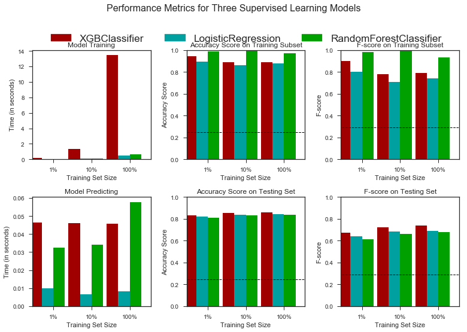

```python
# Import the three supervised learning models from sklearn
from xgboost import XGBClassifier
from sklearn.ensemble import RandomForestClassifier
from sklearn.linear_model import LogisticRegression

# Initialize the three models
clf_A = LogisticRegression(random_state = 0)
clf_B = RandomForestClassifier(random_state = 0)
clf_C = XGBClassifier()

# Calculate the number of samples for 1%, 10%, and 100% of the training data
samples_100 = int(len(y_train))
samples_10 = int(len(y_train)*0.1)
samples_1 = int(len(y_train)*0.01)

# Collect results on the learners
results = {}
for clf in [clf_A, clf_B, clf_C]:
    clf_name = clf.__class__.__name__
    results[clf_name] = {}
    for i, samples in enumerate([samples_1, samples_10, samples_100]):
        results[clf_name][i] = train_predict(clf, samples, X_train, y_train, X_test, y_test)

#Check results in a dataframe (from Reviewer's notes)
for i in results.items():
    print
    print i[0]
    display(pd.DataFrame(i[1]).rename(columns={0:'1% of train', 1:'10% of train', 2:'100% of train'}))
# Run metrics visualization for the three supervised learning models chosen
vs.evaluate(results, accuracy, fscore)
```

## Step 4: Improving Results

### Choosing the Best Model

I will choose the **XGBoost** classifier for the task of identifying individuals that make more than 50k. As it can be observed from the plots, XGBoost outperforms in terms of the F-score and accuracy the other two algorithms at all training set sizes. Comparing the F-score and accuracy on training and testing sets by Random Forest, the much higher scores on training set than testing set indicates the overfitting of the Random Forest model. As for the training and predicting time, Logistic Regression shows the best efficiency.

When weighing all of these attributes, we can conclude that XGBoost is best suited for this problem. Since we are more interested in maximizing the number of accurately classified people that make more than 50K, this model, which has the highest accuracy and F-score, seems to be the most appropriate.

### Describing the Model in Layman's Terms

XGBoost belongs to a family of boosting algorithms that convert weak learners into one strong learner. A weak learner is one which is slightly better at classifying the data than random chance.

In general, boosting is a sequential process; i.e., trees are grown using the information from a previously grown tree one after the other. This process slowly learns from data and tries to improve its prediction in subsequent iterations.The very next model capitalizes on the misclassification/error of previous model and tries to reduce it.

The XGBoost algorithm's goal is to find simple trees to fit on the training data well. Starting from constant prediction (0), during each training iteration, the model adds a new tree that places a higher emphasis on the previously misclassified cases. Over time, the model combines these trees (clues) to understand the dataset when it may seem convoluted to the user. Finally, to make predictions, XGBoost uses the weak independent trees to form the most probable single strong prediction.

Reference: https://www.hackerearth.com/practice/machine-learning/machine-learning-algorithms/beginners-tutorial-on-xgboost-parameter-tuning-r/tutorial/

### Model Tuning

Fine tune the **XGBoost** model by using grid search (`GridSearchCV`).

```
Unoptimized model
------
Accuracy score on testing data: 0.8606
F-score on testing data: 0.7409

Optimized Model
------
Final accuracy score on the testing data: 0.8816
Final F-score on the testing data: 0.7801
```

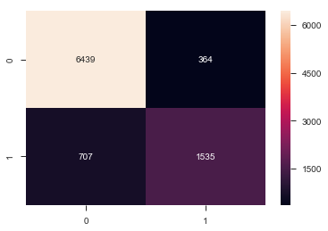

```python
# Import 'GridSearchCV', 'make_scorer', and any other necessary libraries
from sklearn.model_selection import GridSearchCV
from sklearn.metrics import make_scorer
from xgboost import XGBClassifier
from sklearn.model_selection import StratifiedShuffleSplit

# Initialize the classifier
ind_params = { 'seed':0, 'colsample_bytree': 0.8, 'objective': 'binary:logistic', 'min_child_weight': 1}
clf = XGBClassifier(**ind_params)

# Create the parameters list you wish to tune, using a dictionary if needed.
# HINT: parameters = {'parameter_1': [value1, value2], 'parameter_2': [value1, value2]}
cv_params = {'max_depth': [3,5,7],'learning_rate': [0.1, 0.01],'n_estimators':[10,100,1000]}

# Make an fbeta_score scoring object using make_scorer()
scorer = make_scorer(fbeta_score, beta = 0.5)

#As for unbalanced dataset, make sure the labels are evenly split between the validation sets(Reviewer's note)
cv = StratifiedShuffleSplit(n_splits = 5, test_size = 0.2, random_state = 0)

# Perform grid search on the classifier using 'scorer' as the scoring method using GridSearchCV()
grid_obj = GridSearchCV(estimator = clf,param_grid = cv_params, scoring = scorer, cv = cv)

# Fit the grid search object to the training data and find the optimal parameters using fit()
grid_fit = grid_obj.fit(features_final, income)

# Get the estimator
best_clf = grid_fit.best_estimator_

# Make predictions using the unoptimized and model
predictions = (clf.fit(X_train, y_train)).predict(X_test)
best_predictions = best_clf.predict(X_test)

# Report the before-and-afterscores
print "Unoptimized model\n------"
print "Accuracy score on testing data: {:.4f}".format(accuracy_score(y_test, predictions))
print "F-score on testing data: {:.4f}".format(fbeta_score(y_test, predictions, beta = 0.5))
print "\nOptimized Model\n------"
print "Final accuracy score on the testing data: {:.4f}".format(accuracy_score(y_test, best_predictions))
print "Final F-score on the testing data: {:.4f}".format(fbeta_score(y_test, best_predictions, beta = 0.5))

#Exam the final confusion matrix
from sklearn.metrics import confusion_matrix
import seaborn as sns
%matplotlib inline
sns.heatmap(confusion_matrix(y_test, best_predictions),annot = True, fmt = '')
```

### Final Model Evaluation

#### Results:

| Metric | Benchmark Predictor | Unoptimized Model | Optimized Model |
| --- | --- | --- | --- |
| Accuracy Score | 0.2478 | 0.8606 | 0.8816 |
| F-score | 0.2917 | 0.7409 | 0.7801 |

The optimized model's accuracy and F-score on the testing data are slightly better than the unoptimized model. The optimized model's accuracy and F-score on the testing data are much better than the benchmark predictor.

The confusion matrix of the best estimator shows 1535 out of 2242 cases that people make more than 50k have been classified correctly. 364 cases that people make less than 50k have been misclassified as people make more than 50k.

## Step 5: Feature Importance

### Feature Relevance Observation

When **Exploring the Data**, it was shown there are 13 available features for each individual on record in the census data. Of these 13 records, the 5 most important features for prediction are ranked as **capital-gain**, **education-num**, **age**, **capital-loss**, and **hours-per-week**.

The goal is to predict whether an individual makes at most or more than $50,000. Among the five selected features, **capital-gain** and **capital-loss** directly relate to the individual's ability of making money. The feature **education-num** indicates the individual's education level, and usually the higher education received, the better paid. The feature **age** implies the person's working experience. I rank it less important than education because it is common to see a person with high education makes more money than an older person with less education. The last feature I chose is **hours-per-week**, which shows the individual's working status. However, sometimes the long working hours do not guarantee a good salary, and that's why I list it at the last of the five important features.

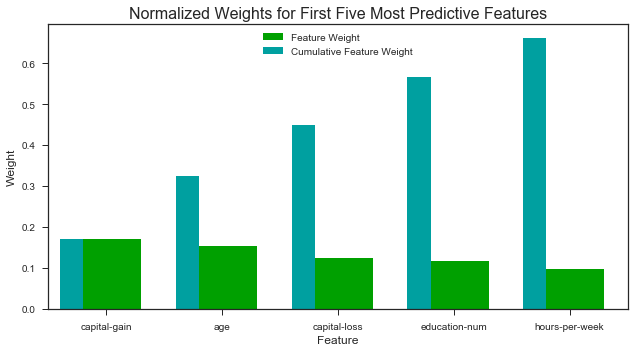

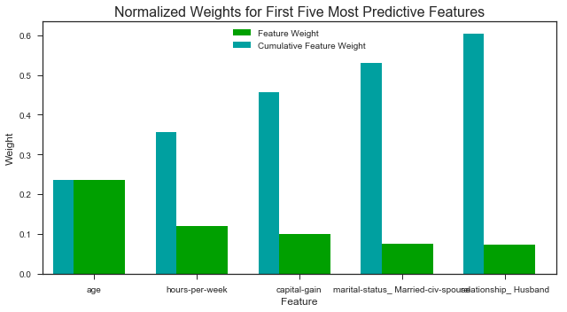

|  | Coef_ | Odds_Ratio_ | P_values |
| --- | --- | --- | --- |
| age | 1.825242 | 6.204294 | 3.747991e-51 |
| education-num | 1.677455 | 5.351916 | 1.786538e-44 |
| capital-gain | 2.323102 | 10.207286 | 0.000000e+00 |
| capital-loss | 1.295168 | 3.651608 | 5.194381e-137 |
| hours-per-week | 2.863487 | 17.522521 | 1.953968e-16 |
| workclass_ Federal-gov | 0.194465 | 1.214661 | 3.730763e-28 |
| workclass_ Local-gov | -0.460225 | 0.631142 | 4.278918e-07 |
| workclass_ Private | -0.267329 | 0.765421 | 4.542286e-30 |
| workclass_ Self-emp-inc | -0.129484 | 0.878549 | 8.067165e-139 |
| workclass_ Self-emp-not-inc | -0.768207 | 0.463844 | 1.097577e-05 |
| workclass_ State-gov | -0.558383 | 0.572133 | 1.473170e-02 |
| workclass_ Without-pay | -0.703754 | 0.494724 | 3.629445e-01 |
| education_level_ 10th | -0.807303 | 0.446059 | 4.396877e-41 |
| education_level_ 11th | -0.814568 | 0.442831 | 2.381749e-57 |
| education_level_ 12th | -0.458006 | 0.632544 | 8.287345e-18 |
| education_level_ 1st-4th | -0.310045 | 0.733414 | 1.133753e-09 |
| education_level_ 5th-6th | -0.817682 | 0.441454 | 1.800079e-19 |
| education_level_ 7th-8th | -1.096461 | 0.334051 | 2.493968e-28 |
| education_level_ 9th | -0.859462 | 0.423390 | 1.298077e-24 |
| education_level_ Assoc-acdm | 0.005511 | 1.005526 | 1.771853e-01 |
| education_level_ Assoc-voc | -0.034672 | 0.965922 | 6.444684e-01 |
| education_level_ Bachelors | 0.428556 | 1.535040 | 2.107132e-210 |
| education_level_ Doctorate | 1.119624 | 3.063701 | 6.077122e-138 |
| education_level_ HS-grad | -0.256077 | 0.774082 | 9.528655e-107 |
| education_level_ Masters | 0.673758 | 1.961595 | 7.663998e-221 |
| education_level_ Preschool | -0.725568 | 0.484050 | 1.037857e-05 |
| education_level_ Prof-school | 1.253592 | 3.502902 | 3.536018e-198 |
| education_level_ Some-college | 0.005885 | 1.005902 | 3.930588e-19 |
| marital-status_ Divorced | -0.886364 | 0.412152 | 1.536835e-123 |
| marital-status_ Married-AF-spouse | 0.739955 | 2.095842 | 3.319995e-01 |
| ... | ... | ... | ... |
| native-country_ Greece | -0.009816 | 0.990232 | 1.008599e-01 |
| native-country_ Guatemala | -0.108397 | 0.897271 | 8.435247e-05 |
| native-country_ Haiti | -0.271789 | 0.762015 | 2.231504e-03 |
| native-country_ Holand-Netherlands | 0.000000 | 1.000000 | NaN |
| native-country_ Honduras | 0.086724 | 1.090596 | 2.137710e-01 |
| native-country_ Hong | -0.175422 | 0.839103 | 9.804199e-01 |
| native-country_ Hungary | 0.402743 | 1.495922 | 1.722699e-01 |
| native-country_ India | -0.197084 | 0.821122 | 1.675912e-04 |
| native-country_ Iran | 0.070009 | 1.072518 | 2.421611e-02 |
| native-country_ Ireland | 0.129474 | 1.138230 | 4.838743e-01 |
| native-country_ Italy | 0.788485 | 2.200060 | 6.324598e-02 |
| native-country_ Jamaica | 0.316805 | 1.372735 | 2.226936e-02 |
| native-country_ Japan | -0.118059 | 0.888644 | 1.482713e-01 |
| native-country_ Laos | -0.865250 | 0.420947 | 5.883202e-02 |
| native-country_ Mexico | -0.625973 | 0.534741 | 7.158309e-36 |
| native-country_ Nicaragua | -0.399434 | 0.670699 | 3.179051e-03 |
| native-country_ Outlying-US(Guam-USVI-etc) | -0.038666 | 0.962072 | 1.263196e-01 |
| native-country_ Peru | -0.556340 | 0.573304 | 1.589467e-02 |
| native-country_ Philippines | 0.189351 | 1.208464 | 2.034416e-01 |
| native-country_ Poland | 0.238235 | 1.269007 | 3.221401e-01 |
| native-country_ Portugal | 0.903106 | 2.467254 | 5.261475e-01 |
| native-country_ Puerto-Rico | -0.163277 | 0.849356 | 6.806416e-05 |
| native-country_ Scotland | -0.856860 | 0.424493 | 8.596992e-02 |
| native-country_ South | -0.909981 | 0.402532 | 2.233639e-01 |
| native-country_ Taiwan | -0.231444 | 0.793387 | 1.044852e-03 |
| native-country_ Thailand | -0.601788 | 0.547831 | 3.108711e-01 |
| native-country_ Trinadad&Tobago | -1.158477 | 0.313964 | 2.167128e-02 |
| native-country_ United-States | 0.349615 | 1.418522 | 2.221822e-02 |
| native-country_ Vietnam | -1.026830 | 0.358141 | 1.954072e-03 |
| native-country_ Yugoslavia | 0.859973 | 2.363096 | 1.150018e-01 |

103 rows × 3 columns

```python
# Import a supervised learning model that has 'feature_importances_'
from xgboost import XGBClassifier
from sklearn.ensemble import RandomForestClassifier

# Train the supervised model on the training set using .fit(X_train, y_train)
model = XGBClassifier().fit(X_train, y_train)
model_1 = RandomForestClassifier(random_state = 0).fit(X_train, y_train)

# Extract the feature importances using .feature_importances_
importances = model.feature_importances_
importances_1 = model_1.feature_importances_

# Plot
vs.feature_plot(importances, X_train, y_train)
vs.feature_plot(importances_1, X_train, y_train)

# Compare with Logistic Regression
from sklearn.feature_selection import chi2
from sklearn.linear_model import LogisticRegression

model_2 = LogisticRegression().fit(X_train, y_train)

scores, pvalues = chi2(X_train, y_train)

coef = pd.DataFrame(zip(model_2.coef_.T, np.exp(model_2.coef_).T))
coef.columns = ['Coef_','Odds_Ratio_']
coef['P_values'] = pvalues
coef.index = X_train.columns

coef.Coef_ = coef.Coef_.astype(np.float64)
coef.Odds_Ratio_ = coef.Odds_Ratio_.astype(np.float64)

coef
```

### Extracting Feature Importance

I have applied both XGBoost classifier and Random Forests classifier to identify the five most importantce features, and the results are slightly different. The volatility in the feature importance scores depends on the degree of "redundancy" in the features, where "redundancy" could be measured in correlation and mutual information.

I have also check the odss-ratio of features as for Logistic Regression. The odds-ratio of a feature represents the constant effect of a feature on the likelihood that one outcome (in this case is the prediction of people make more than 50k) will occur. Thus, a feature is more important with a higher odds-ratio.

Both graphs shows that the five most important features add up to more than half of the importance of all features.

The result from Random Forest also counts 'relationship_Husband' and 'marital-status_Married-civ-spouse', which makes sense since the husband of a household is the main income source for most families.

```python
# Import functionality for cloning a model
from sklearn.base import clone

# Reduce the feature space
X_train_reduced = X_train[X_train.columns.values[(np.argsort(importances_1)[::-1])[:5]]]
X_test_reduced = X_test[X_test.columns.values[(np.argsort(importances_1)[::-1])[:5]]]

# Train on the "best" model found from grid search earlier
clf = (clone(best_clf)).fit(X_train_reduced, y_train)

# Make new predictions
reduced_predictions = clf.predict(X_test_reduced)

# Apply train_predict to compare the time used by full/reduced datasets
results_full = train_predict(best_clf, int(len(y_train)), X_train, y_train, X_test, y_test)
results_reduced = train_predict(best_clf, int(len(y_train)), X_train_reduced, y_train, X_test_reduced, y_test)

# Report scores and time used from the final model using both versions of data
print "Final Model trained on full data\n------"
print "Accuracy on testing data: {:.4f}".format(accuracy_score(y_test, best_predictions))
print "F-score on testing data: {:.4f}".format(fbeta_score(y_test, best_predictions, beta = 0.5))
print "Train time: {:.4f}".format(results_full['train_time'])
print "Prediction time: {:.4f}".format(results_full['pred_time'])
print "\nFinal Model trained on reduced data\n------"
print "Accuracy on testing data: {:.4f}".format(accuracy_score(y_test, reduced_predictions))
print "F-score on testing data: {:.4f}".format(fbeta_score(y_test, reduced_predictions, beta = 0.5))
print "Train time: {:.4f}".format(results_reduced['train_time'])
print "Prediction time: {:.4f}".format(results_reduced['pred_time'])
```

```
XGBClassifier trained on 36177 samples.
XGBClassifier trained on 36177 samples.
Final Model trained on full data
------
Accuracy on testing data: 0.8816
F-score on testing data: 0.7801
Train time: 104.4216
Prediction time: 0.2573

Final Model trained on reduced data
------
Accuracy on testing data: 0.8214
F-score on testing data: 0.6444
Train time: 8.4925
Prediction time: 0.2719
```

### Effects of Feature Selection

The final model's accuracy score on the reduced data using only five features is 0.8214, which is 7% lower than that using all features (0.8816).

If training time was a factor, I would consider using the reduced data as the training set. From the time analysis above, the model training time (8.4925s) on the reduced dataset is only 8% of the time (104.42s) training on the full dataset.